# Meta-análise anti-inflamatórios não esteroidais e biomarcadores em peixes

Luiz Henrique Z Justi, Juh F Silva, Izonete Cristina Guiloski e [Henrique Laureano](https://henriquelaureano.github.io/)

Last modification on* 2022-03-08 16:00:32

# Tipo de exposição x Medicamentos x Marcadores

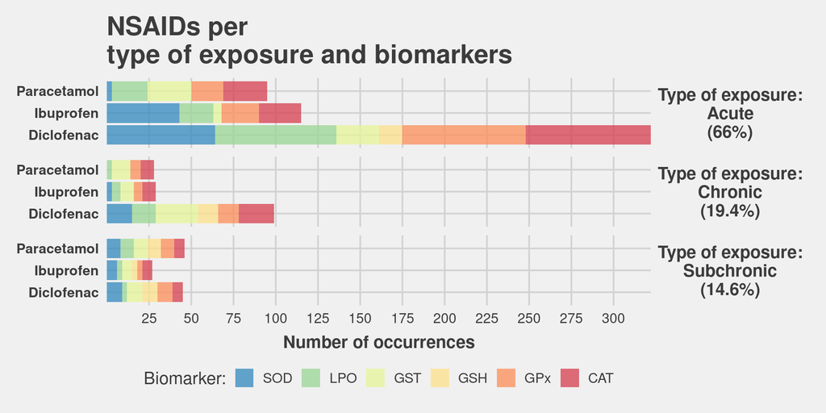

# Concentração x Medicamentos x Marcadores

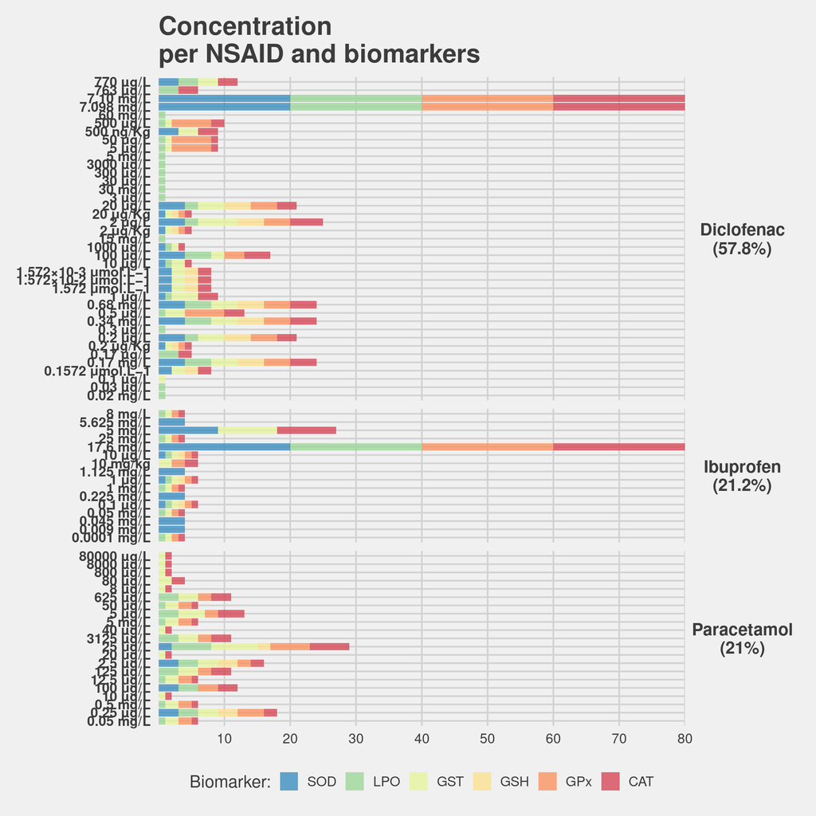

> There are too many drugs, it will be better to split by NSAIDs

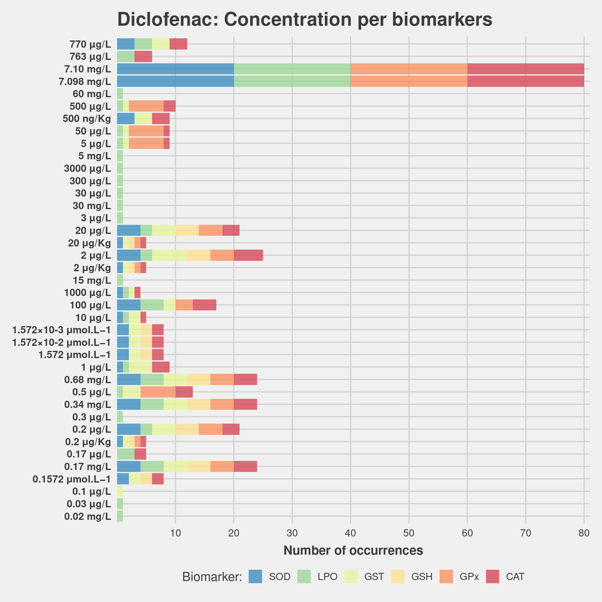

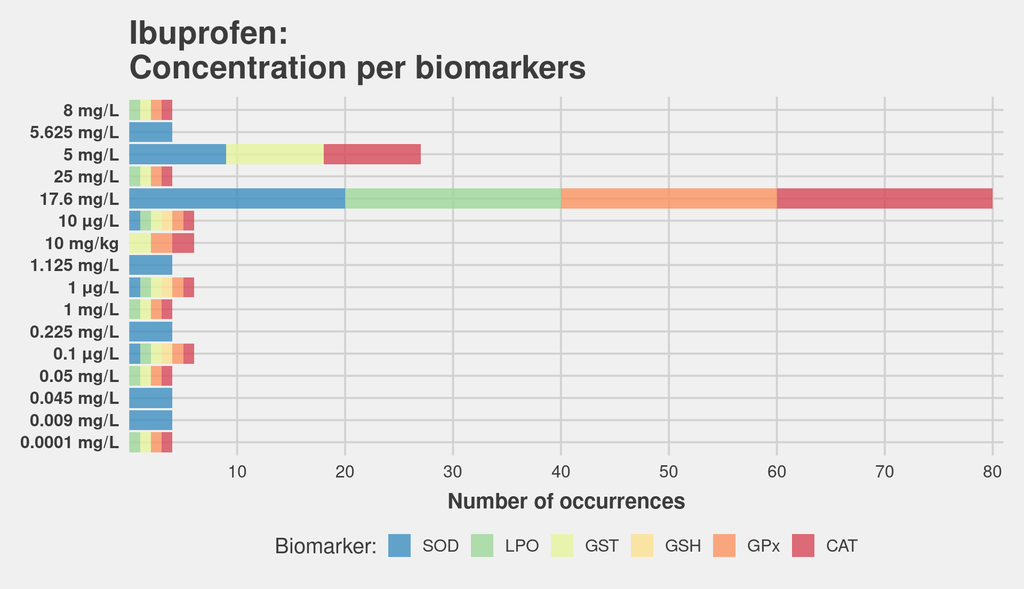

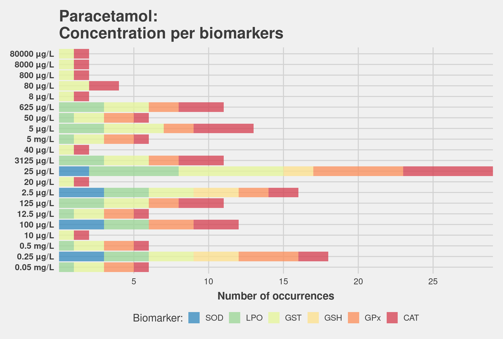

# Espécie de peixe x Medicamentos

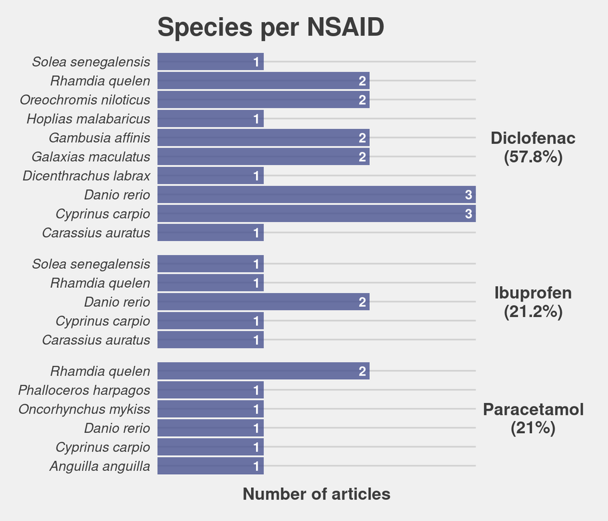

# Espécie de peixe x Medicamentos x Marcadores

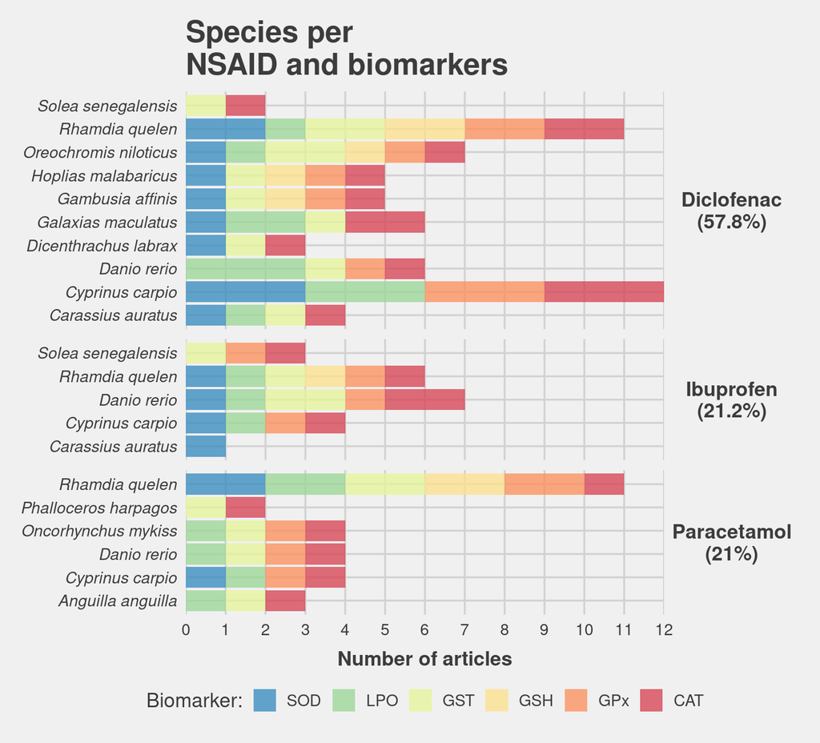

# Órgãos x Medicamentos

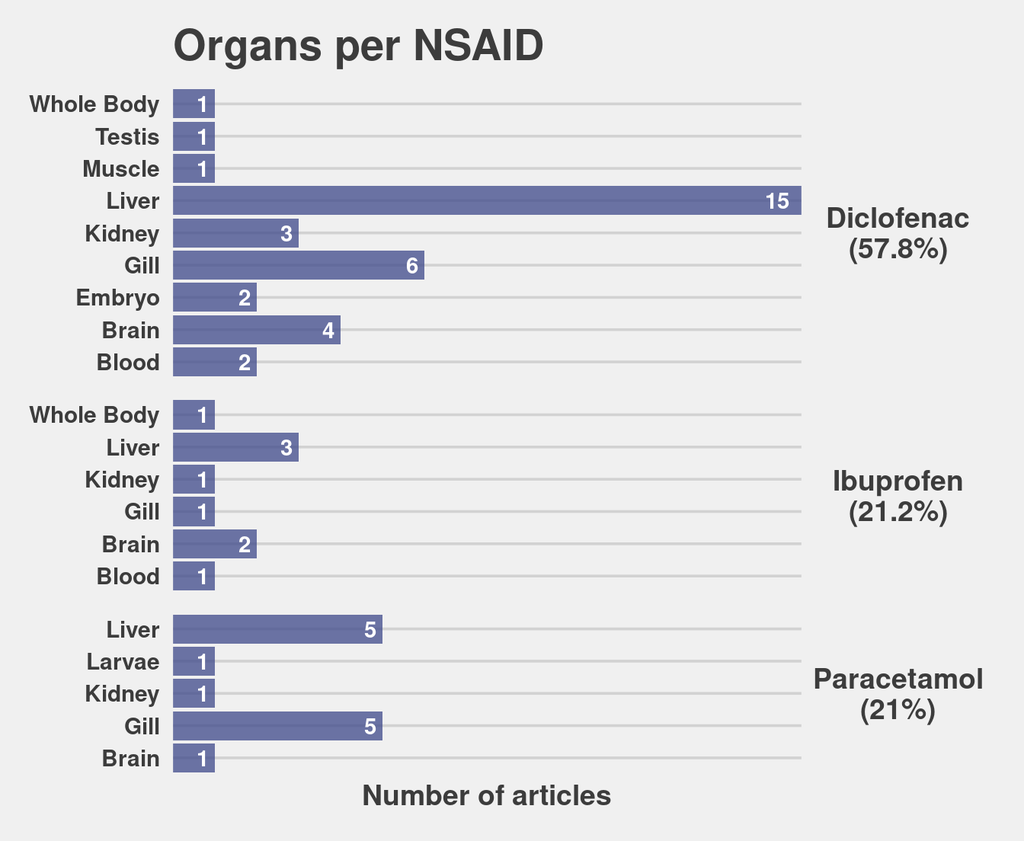

# Órgãos x Medicamentos x Marcadores

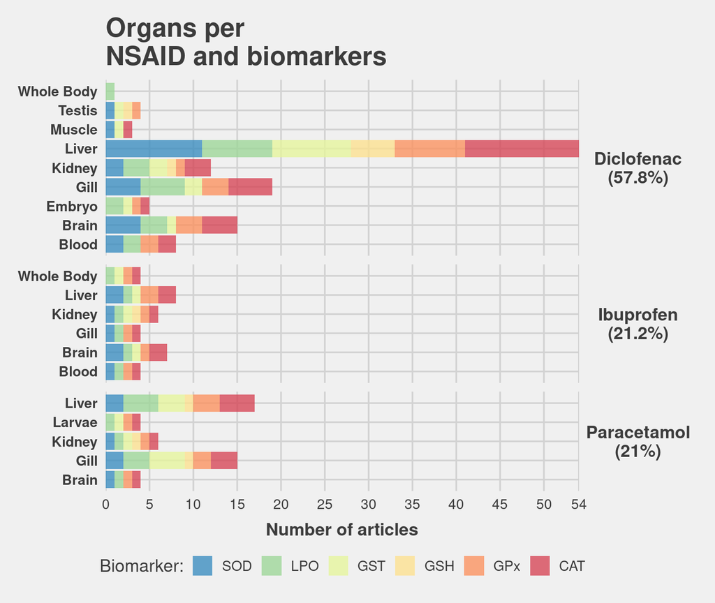

# Forma de exposição x Medicamentos x Marcadores

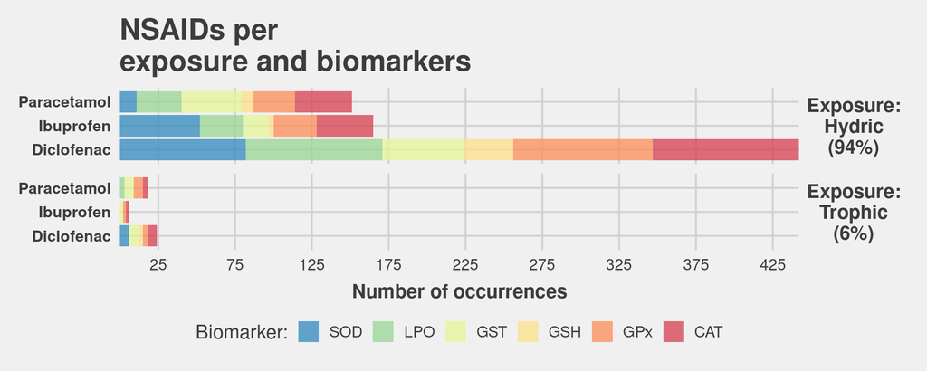

# Exposição x Anti-inflamatório x Órgãos x Marcadores

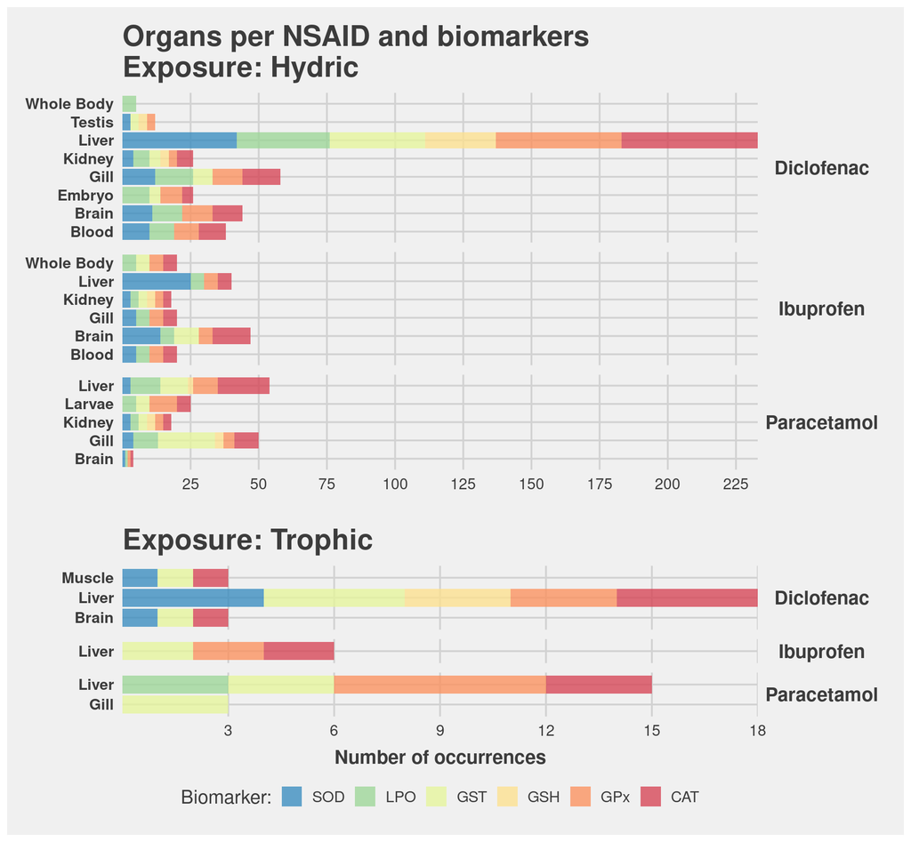

# Time of exposure

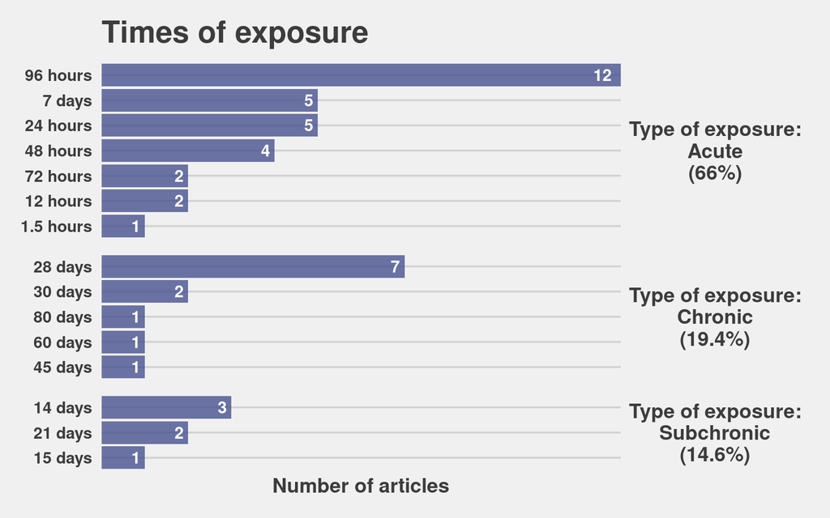

# Meta-análise

> We fitted a model for each biomarker. In each model, we used the following variables/moderators: `Type of exposure` (3 levels); `NSAID` (3 levels), `Dose` (2 levels), and `Exposure` (2 levels).

> We controlled the variance for the different papers and fish species.

> The chosen measure to model the difference between treatment and control was the **log response ratio** (lnRR)

> $$\text{lnRR} =
> \log (\text{Response Ratio}) =
> \log \Big(\frac{\text{Treatment}}{\text{Control}}\Big).$$

> The log transformation is applied to have a sampling distribution centered around zero (useful to get more reliable *p*-values).

> Below, we have the model results. Global effect means a model without decomposing the lnRR by any moderator. SE means the standard error (the uncertainty around the lnRR estimate). ci.lb and ci.up are the lower and upper bounds of a 95% confidence interval for the lnRR. Finally, pval is the *p*-value (in red, all *p*-values $\leq$ 0.05).

|  | Effect | lnRR | SE | ci.lb | ci.ub | pval |
| --- | --- | --- | --- | --- | --- | --- |
| **CAT** |  |  |  |  |  |  |
| Global effect | Global effect | 0.0163 | 0.1610 | -0.2994 | 0.3319 | 0.9195 |
| Type of exposure | Acute | 0.2778 | 0.1610 | -0.0377 | 0.5934 | 0.0844 |
| Type of exposure | Chronic | -0.3186 | 0.1618 | -0.6356 | -0.0015 | 0.0489 |
| Type of exposure | Subchronic | -0.4260 | 0.1618 | -0.7431 | -0.1090 | 0.0085 |
| NSAID | Diclofenac | 0.0155 | 0.1066 | -0.1933 | 0.2244 | 0.8841 |
| NSAID | Ibuprofen | 0.0554 | 0.1085 | -0.1572 | 0.2679 | 0.6097 |
| NSAID | Paracetamol | -0.0072 | 0.1309 | -0.2637 | 0.2492 | 0.9558 |
| Dose | High | 0.0888 | 0.1614 | -0.2275 | 0.4051 | 0.5822 |
| Dose | Low | -0.0333 | 0.1602 | -0.3473 | 0.2806 | 0.8351 |
| Exposure | Hydric | 0.0886 | 0.1621 | -0.2291 | 0.4063 | 0.5846 |
| Exposure | Trophic | -0.2856 | 0.1788 | -0.6361 | 0.0649 | 0.1103 |
| **GPx** |  |  |  |  |  |  |
| Global effect | Global effect | 0.4192 | 0.1221 | 0.1798 | 0.6586 | 0.0006 |
| Type of exposure | Acute | 0.5723 | 0.1338 | 0.3100 | 0.8346 | 0.0000 |
| Type of exposure | Chronic | 0.2072 | 0.1449 | -0.0769 | 0.4913 | 0.1528 |
| Type of exposure | Subchronic | 0.2024 | 0.1449 | -0.0816 | 0.4865 | 0.1625 |
| NSAID | Diclofenac | 0.3493 | 0.1200 | 0.1140 | 0.5846 | 0.0036 |
| NSAID | Ibuprofen | 0.2358 | 0.1242 | -0.0077 | 0.4793 | 0.0577 |
| NSAID | Paracetamol | 0.7612 | 0.1288 | 0.5087 | 1.0137 | 0.0000 |
| Dose | High | 0.2133 | 0.1173 | -0.0167 | 0.4433 | 0.0691 |
| Dose | Low | 0.5990 | 0.1172 | 0.3692 | 0.8288 | 0.0000 |
| Exposure | Hydric | 0.5451 | 0.1421 | 0.2666 | 0.8236 | 0.0001 |
| Exposure | Trophic | 0.0436 | 0.1922 | -0.3332 | 0.4204 | 0.8207 |
| **GSH** |  |  |  |  |  |  |
| Global effect | Global effect | 0.0635 | 0.0896 | -0.1121 | 0.2390 | 0.4785 |
| Type of exposure | Acute | -0.0872 | 0.1042 | -0.2915 | 0.1171 | 0.4029 |
| Type of exposure | Chronic | 0.1191 | 0.0881 | -0.0535 | 0.2917 | 0.1761 |
| Type of exposure | Subchronic | 0.1416 | 0.0881 | -0.0309 | 0.3142 | 0.1077 |
| NSAID | Diclofenac | 0.1365 | 0.1622 | -0.1814 | 0.4545 | 0.4000 |
| NSAID | Ibuprofen | 0.0777 | 0.3569 | -0.6218 | 0.7772 | 0.8276 |
| NSAID | Paracetamol | -0.3677 | 0.1978 | -0.7553 | 0.0199 | 0.0630 |
| Dose | High | -0.0829 | 0.1956 | -0.4664 | 0.3006 | 0.6718 |
| Dose | Low | 0.1094 | 0.1106 | -0.1074 | 0.3261 | 0.3227 |
| Exposure | Hydric | 0.0093 | 0.1047 | -0.1959 | 0.2145 | 0.9293 |
| Exposure | Trophic | 0.2465 | 0.1947 | -0.1350 | 0.6281 | 0.2054 |
| **GST** |  |  |  |  |  |  |
| Global effect | Global effect | -0.0695 | 0.1726 | -0.4079 | 0.2688 | 0.6871 |
| Type of exposure | Acute | -0.0670 | 0.1735 | -0.4071 | 0.2731 | 0.6995 |
| Type of exposure | Chronic | -0.0758 | 0.1734 | -0.4156 | 0.2640 | 0.6620 |
| Type of exposure | Subchronic | -0.0632 | 0.1734 | -0.4030 | 0.2766 | 0.7153 |
| NSAID | Diclofenac | 0.1006 | 0.2232 | -0.3369 | 0.5382 | 0.6521 |
| NSAID | Ibuprofen | 0.1928 | 0.4396 | -0.6688 | 1.0544 | 0.6609 |
| NSAID | Paracetamol | -0.6229 | 0.2299 | -1.0734 | -0.1724 | 0.0067 |
| Dose | High | -0.0894 | 0.1742 | -0.4308 | 0.2520 | 0.6078 |
| Dose | Low | -0.0592 | 0.1733 | -0.3989 | 0.2804 | 0.7325 |
| Exposure | Hydric | -0.0699 | 0.1755 | -0.4138 | 0.2741 | 0.6906 |
| Exposure | Trophic | -0.0683 | 0.2142 | -0.4882 | 0.3516 | 0.7499 |
| **LPO** |  |  |  |  |  |  |
| Global effect | Global effect | 0.1147 | 0.1247 | -0.1298 | 0.3592 | 0.3577 |
| Type of exposure | Acute | 0.1302 | 0.1443 | -0.1526 | 0.4130 | 0.3670 |
| Type of exposure | Chronic | 0.1386 | 0.1747 | -0.2039 | 0.4811 | 0.4278 |
| Type of exposure | Subchronic | 0.0338 | 0.1751 | -0.3095 | 0.3771 | 0.8470 |
| NSAID | Diclofenac | -0.1355 | 0.1244 | -0.3794 | 0.1083 | 0.2760 |
| NSAID | Ibuprofen | 0.1037 | 0.1262 | -0.1437 | 0.3510 | 0.4115 |
| NSAID | Paracetamol | 0.5542 | 0.1388 | 0.2822 | 0.8263 | 0.0001 |
| Dose | High | 0.1332 | 0.1265 | -0.1146 | 0.3810 | 0.2922 |
| Dose | Low | 0.0946 | 0.1265 | -0.1534 | 0.3426 | 0.4546 |
| Exposure | Hydric | 0.1091 | 0.1231 | -0.1323 | 0.3504 | 0.3757 |
| Exposure | Trophic | 0.3095 | 0.2790 | -0.2375 | 0.8564 | 0.2674 |
| **SOD** |  |  |  |  |  |  |
| Global effect | Global effect | 0.1948 | 0.1116 | -0.0240 | 0.4135 | 0.0809 |
| Type of exposure | Acute | 0.1754 | 0.0973 | -0.0153 | 0.3662 | 0.0714 |
| Type of exposure | Chronic | 0.1888 | 0.0982 | -0.0036 | 0.3813 | 0.0544 |
| Type of exposure | Subchronic | 0.1890 | 0.0982 | -0.0034 | 0.3814 | 0.0542 |
| NSAID | Diclofenac | 0.1463 | 0.1048 | -0.0592 | 0.3518 | 0.1628 |
| NSAID | Ibuprofen | 0.2100 | 0.1072 | -0.0002 | 0.4201 | 0.0502 |
| NSAID | Paracetamol | 0.4329 | 0.1279 | 0.1822 | 0.6837 | 0.0007 |
| Dose | High | 0.0109 | 0.1287 | -0.2414 | 0.2632 | 0.9324 |
| Dose | Low | 0.3220 | 0.1275 | 0.0720 | 0.5720 | 0.0116 |
| Exposure | Hydric | 0.1774 | 0.1124 | -0.0430 | 0.3978 | 0.1147 |
| Exposure | Trophic | 0.2170 | 0.2486 | -0.2703 | 0.7042 | 0.3828 |

> Everything that is present in the table, now visually:

> The dots are the mean lnRR and the horizontal lines are the 95% confidence intervals.

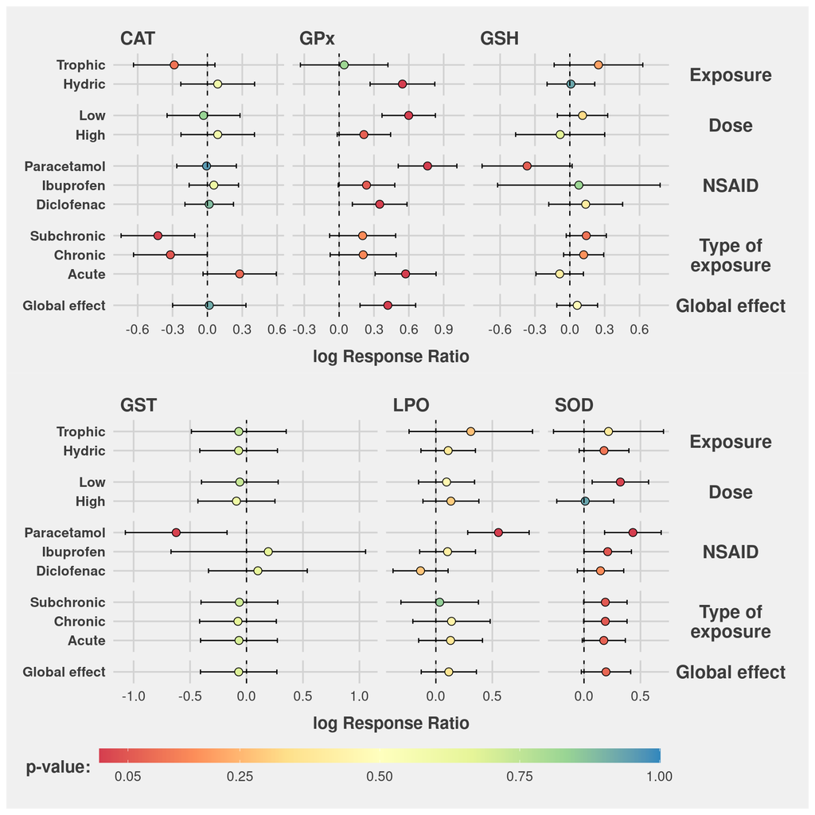

> Another graphs that we can do are the caterpillar and the orchard plots. In these graphs, instead of looking at the mean lnRR, we look at each lnRR.

> Perform those plots to each biomarker and moderator is unviable. Thus, we choose to perform for the NSAID at the GST biomarker (where we have the biggest confidence interval). *k* means the number of effects/lines in the dataset.

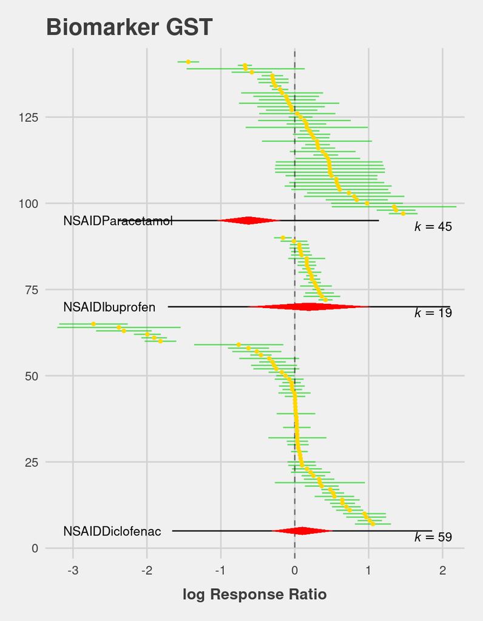

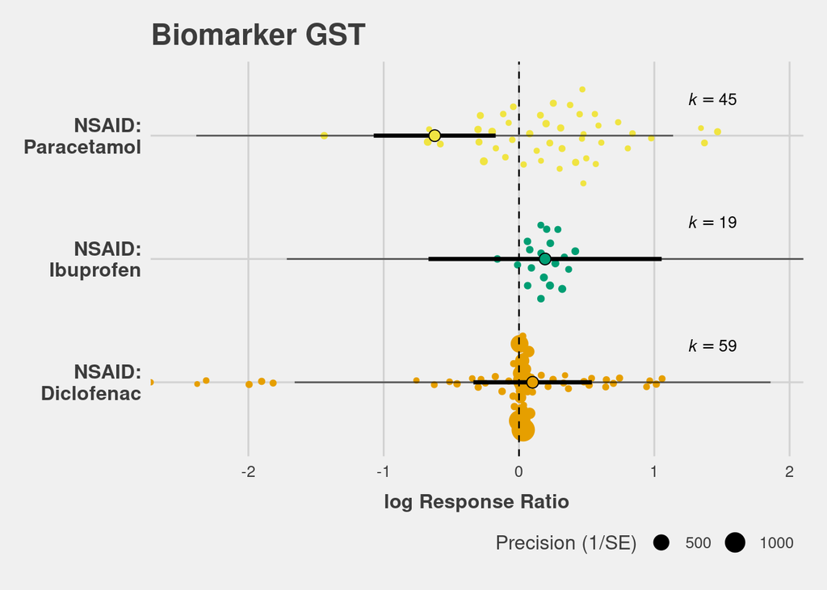

> Besides all that, we also have some standard measures/metrics in a meta-analysis. They are:
> - *Q*: Cochran’s test statistic for the residual heterogeneity, approximated from a chi-square distribution;
> - $Q_{M}$: if the variables/moderators are statistically significant;
> - $R^{2}$: the proportion of the (response) variance/heterogeneity that’s explained by the moderator(s);
> - $I^{2}$: the estimated amount of heterogeneity relative to the total amount of variance in the observed effects;
> - $\tau^{2}$: estimated amount of residual heterogeneity.

> In red, all significant *p*-values ($\leq$ 0.05).

|  | Q | Q.pvalue | Qm | Qm.pvalue | R2 | i2.Specie | i2.Author | i2.total | tau2 |
| --- | --- | --- | --- | --- | --- | --- | --- | --- | --- |
| **CAT** |  |  |  |  |  |  |  |  |  |
| Global effect | 33216.198 | <.0001 | 0.0102 | 0.9195 | 0.00 | 49.99 | 49.99 | 99.97 | 0 |
| Type of exposure | 26906.216 | <.0001 | 5841.1100 | <.0001 | 18.12 | 49.99 | 49.99 | 99.97 | 0 |
| NSAID | 33173.219 | <.0001 | 2.4948 | 0.2872 | 0.23 | 20.21 | 79.74 | 99.95 | 0 |
| Dose | 33006.317 | <.0001 | 7.0698 | 0.0078 | 0.92 | 49.99 | 49.99 | 99.97 | 0 |
| Exposure | 33215.720 | <.0001 | 15.0525 | 0.0001 | 2.02 | 49.99 | 49.99 | 99.97 | 0 |
| All/Full | 25306.379 | <.0001 | 5848.7672 | <.0001 | 26.77 | 41.19 | 58.77 | 99.96 | 0 |
| **GPx** |  |  |  |  |  |  |  |  |  |
| Global effect | 27605.275 | <.0001 | 11.7778 | 0.0006 | 0.00 | 38.67 | 61.26 | 99.93 | 0 |
| Type of exposure | 10714.867 | <.0001 | 14.6732 | 0.0007 | 14.45 | 16.42 | 83.52 | 99.93 | 0 |
| NSAID | 27117.247 | <.0001 | 48.5728 | <.0001 | 19.35 | 37.01 | 62.91 | 99.92 | 0 |
| Dose | 13324.834 | <.0001 | 488.9567 | <.0001 | 21.29 | 42.36 | 57.56 | 99.92 | 0 |
| Exposure | 27519.099 | <.0001 | 7.5467 | 0.0060 | 8.67 | 46.63 | 53.31 | 99.94 | 0 |
| All/Full | 9240.473 | <.0001 | 560.3584 | <.0001 | 29.71 | 46.29 | 53.66 | 99.95 | 0 |
| **GSH** |  |  |  |  |  |  |  |  |  |
| Global effect | 3937.031 | <.0001 | 0.5023 | 0.4785 | 0.00 | 67.05 | 32.47 | 99.53 | 0 |
| Type of exposure | 3896.127 | <.0001 | 34.3951 | <.0001 | 28.04 | 91.07 | 8.34 | 99.42 | 0 |
| NSAID | 3928.193 | <.0001 | 14.8322 | 0.0006 | 23.22 | 35.98 | 63.89 | 99.87 | 0 |
| Dose | 3923.057 | <.0001 | 0.7318 | 0.3923 | 15.99 | 71.29 | 28.30 | 99.59 | 0 |
| Exposure | 3900.240 | <.0001 | 1.1521 | 0.2831 | 9.12 | 71.80 | 27.75 | 99.55 | 0 |
| All/Full | 3746.585 | <.0001 | 46.4606 | <.0001 | 26.94 | 43.74 | 56.11 | 99.85 | 0 |
| **GST** |  |  |  |  |  |  |  |  |  |
| Global effect | 4711.407 | <.0001 | 0.1622 | 0.6871 | 0.00 | 7.60 | 92.40 | 99.99 | 0 |
| Type of exposure | 4487.821 | <.0001 | 216.1268 | <.0001 | 0.00 | 7.60 | 92.39 | 99.99 | 0 |
| NSAID | 4487.393 | <.0001 | 62.6083 | <.0001 | 14.80 | 4.97 | 95.03 | 100.00 | 0 |
| Dose | 4705.831 | <.0001 | 0.9257 | 0.3360 | 0.04 | 7.52 | 92.48 | 99.99 | 0 |
| Exposure | 4352.088 | <.0001 | 0.0001 | 0.9919 | 0.00 | 7.79 | 92.21 | 99.99 | 0 |
| All/Full | 3828.354 | <.0001 | 279.7792 | <.0001 | 14.68 | 5.04 | 94.96 | 100.00 | 0 |
| **LPO** |  |  |  |  |  |  |  |  |  |
| Global effect | 5005.395 | <.0001 | 0.8459 | 0.3577 | 0.00 | 8.18 | 89.93 | 98.11 | 0 |
| Type of exposure | 4994.139 | <.0001 | 25.1392 | <.0001 | 0.34 | 7.68 | 90.55 | 98.23 | 0 |
| NSAID | 4927.748 | <.0001 | 136.1245 | <.0001 | 27.15 | 10.55 | 87.33 | 97.88 | 0 |
| Dose | 4978.351 | <.0001 | 2.9846 | 0.0841 | 0.14 | 8.19 | 89.96 | 98.14 | 0 |
| Exposure | 4993.172 | <.0001 | 0.6038 | 0.4371 | 0.36 | 7.94 | 90.11 | 98.06 | 0 |
| All/Full | 4865.351 | <.0001 | 166.7812 | <.0001 | 28.75 | 17.73 | 80.26 | 97.99 | 0 |
| **SOD** |  |  |  |  |  |  |  |  |  |
| Global effect | 14186.396 | <.0001 | 3.0459 | 0.0809 | 0.00 | 41.16 | 58.75 | 99.91 | 0 |
| Type of exposure | 14047.891 | <.0001 | 0.1220 | 0.9408 | 0.04 | 17.95 | 81.95 | 99.90 | 0 |
| NSAID | 13982.771 | <.0001 | 16.8571 | 0.0002 | 4.18 | 23.27 | 76.64 | 99.91 | 0 |
| Dose | 14167.109 | <.0001 | 51.4823 | <.0001 | 10.96 | 28.89 | 71.04 | 99.93 | 0 |
| Exposure | 14182.702 | <.0001 | 0.0210 | 0.8847 | 0.05 | 23.27 | 76.63 | 99.90 | 0 |
| All/Full | 13728.739 | <.0001 | 68.8970 | <.0001 | 15.05 | 35.96 | 63.97 | 99.94 | 0 |

> Also, we can make the funnel plots to evaluate some possible publication bias. The desired behavior is all points symmetrically dispersed around zero, and all (ideally) in the white background region.

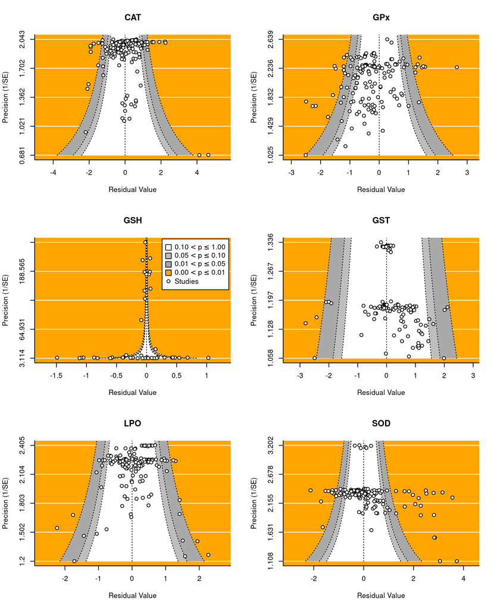

# Referências

> The statistical analysis was performed with the `R` language and environment for statistical computing (R Core Team, 2021). Barplots and percentage computations were used to describe and summarize the qualitative variables. A meta-analysis (Viechtbauer, 2010) was performed for each biomarker to understand and summarize the findings of the articles, in terms of type of exposure; NSAID; dose; and exposure. The main `R` packages used in this analysis were: {`dplyr`} (Wickham et al., 2021), {`tidyr`} (Wickham, 2021), {`stringr`} (Wickham, 2019), {`ggplot2`} (Wickham, 2016), {`purrr`} (Henry and Wickham, 2020), {`metafor`} (Viechtbauer, 2010), and {`orchaRd`} (Noble, 2022).

> R Core Team (2021). R: A language and environment for statistical computing. R Foundation for Statistical Computing, Vienna, Austria. URL https://www.R-project.org/

> Wickham, H., François, R., Henry, L., Müller, K. (2021). dplyr: A Grammar of Data Manipulation. R package version 1.0.7. https://CRAN.R-project.org/package=dplyr

> Wickham, H. (2021). tidyr: Tidy Messy Data. R package version 1.1.3. https://CRAN.R-project.org/package=tidyr

> Wickham, H. (2019). stringr: Simple, Consistent Wrappers for Common String Operations. R package version 1.4.0. https://CRAN.R-project.org/package=stringr

> Wickham, H. (2016). ggplot2: Elegant Graphics for Data Analysis. Springer-Verlag New York

> Henry, L., Wickham, H. (2020). purrr: Functional Programming Tools. R package version 0.3.4. https://CRAN.R-project.org/package=purrr

> Viechtbauer, W. (2010). Conducting meta-analyses in R with the metafor package. Journal of Statistical Software, 36(3), 1-48. https://doi.org/10.18637/jss.v036.i03

> Noble, D. (2022). orchaRd: Orchard Plots and Prediction Intervals for Meta-analysis. R package version 0.0.0.9000.